# Cancer genome sequencing report for precision oncology - tumor_sample.BRCA

March 28, 2017

## Annotation sources

The annotated variants are based on the following underlying tools and knowledge resources:

- [VEP v85](http://www.ensembl.org/info/docs/tools/vep/index.html) - Variant Effect Predictor release 85 ([GENCODE v19](https://www.gencodegenes.org/releases/19.html) as the gene reference dataset)
- [COSMIC](http://cancer.sanger.ac.uk/cosmic/) - catalogue of somatic mutations in cancer (v80 (February 2017))
- [dBNSFP](https://sites.google.com/site/jpopgen/dbNSFP) - database of non-synonymous functional predictions (v3.4 (March 2017))
- [ICGC](https://dcc.icgc.org/) - Somatic mutations discovered in all ICGC tumor cohorts (Release 23 (December 2016))
- [ExAC](http://exac.broadinstitute.org/) - germline variant frequencies exome-wide (v1.0 (February 2017))
- [dbSNP](http://www.ncbi.nlm.nih.gov/SNP/) - database of short genetic variants (build 147 (April 2016))
- 1000Genomes - germline variant (phase 3 (20130502))
- [ClinVar](http://www.ncbi.nlm.nih.gov/clinvar/) - database of clinically related variants (March 2017 (20170302))
- [DoCM](http://docm.genome.wustl.edu) - database of curated mutations (v3.2 (April 2016))
- [CIViC](http://civic.genome.wustl.edu) - clinical interpretations of variants in cancer (March 17th 2017)
- [CBMDB](http://www.cancergenomeinterpreter.org/biomarkers) - Cancer Biomarkers database (February 8th 2017)
- [IntOGen catalog of driver mutations](https://www.intogen.org/downloads) - (2016.05)
- [Cancer Hotspots](http://cancerhotspots.org) - a resource for statistically significant mutations in cancer (2016)
- [UniProt/SwissProt KnowledgeBase](http://www.uniprot.org) - resource on protein sequence and functional information (release 2017_03)
- [Pfam](http://pfam.xfam.org) - database of protein families and domains (v31.0 (March 2017))
- [DGIdb](http://dgidb.genome.wustl.edu) - database of interactions betweeen antineoplastic drugs and human proteins (v2.22 (February 2016))
- [TSGene](http://bioinfo.mc.vanderbilt.edu/TSGene/) - tumor suppressor/oncogene database (v2.0 (2016))
- [KEGG pathways](http://www.genome.jp/kegg/pathway.html) - KEGG pathway database (March 9th 2017)

## Somatic SNVs/InDels

### Tier 1 - genomic biomarkers for diagnosis, prognosis, and drug sensitivity

- A total of **1** unique, somatic variant(s) in the tumor sample can be mapped to genomic biomarkers in the [database for clinical interpretations of variants in cancer, CIViC](https://civic.genome.wustl.edu/#/home) or [Cancer bioMarkers database](https://www.cancergenomeinterpreter.org/biomarkers), with the following number of evidence items:
  - Tier 1A: **13** evidence items linked to specific amino acid changes
  - Tier 1B: **0** evidence items linked to codon alterations
  - Tier 1C: **1** evidence items linked to exon alterations

#### Tier 1A biomarkers

The table below lists all variant-evidence item associations:

|  | SYMBOL | PROTEIN_CHANGE | CLINICAL_SIGNIFICANCE | EVIDENCE_LEVEL | EVIDENCE_TYPE | EVIDENCE_DIRECTION | DISEASE_NAME | DESCRIPTION | GENE_NAME | KEGG_PATHWAY | CITATION | DRUG_NAMES | RATING | PROTEIN_DOMAIN | PROTEIN_FEATURE | CDS_CHANGE | CANCER_MUTATION_HOTSPOT | OTHER_LITERATURE_DOCM | OTHER_DISEASE_DOCM | INTOGEN_DRIVER_MUT | CONSEQUENCE | PREDICTED_EFFECT | VEP_ALL_CONSEQUENCE | DBSNP | COSMIC | COSMIC_SITE_HISTOLOGY | CLINVAR | GENOME_VERSION | GENOMIC_CHANGE |
| --- | --- | --- | --- | --- | --- | --- | --- | --- | --- | --- | --- | --- | --- | --- | --- | --- | --- | --- | --- | --- | --- | --- | --- | --- | --- | --- | --- | --- | --- |
| 1 | PIK3CA | p.H1047R | Resistance or Non-Response | B: Clinical evidence | Predictive | Supports | Colorectal Cancer | The presence of a PIK3CA mutation in exon 9 or exon 20 (such as H1047R) were associated with lack of panitumumab or cetuximab response. | phosphatidylinositol-4,5-bisphosphate 3-kinase, catalytic subunit alpha | Carbohydrate metabolism:Inositol phosphate metabolism, Signal transduction:ErbB signaling pathway, Signal transduction:Ras signaling pathway, Signal transduction:Rap1 signaling pathway, Signal transdu… | Sartore-Bianchi et al., 2009, Cancer Res. | Cetuximab, Panitumumab | 3 |  |  | missense_variant:ENST00000263967.3:c.3140A>G:exon21:p.H1047R | PIK3CA\|H1047\|0 | Samuels et al., 2004, Science, Bachman et al., 2004, Cancer Biol. Ther., Kang et al., 2005, Proc. Natl. Acad. Sci. U.S.A., Saal et al., 2005, Cancer Res., Engelman et al., 2006, J. Clin. Invest., Kawa… | lung_squamous_cell_carcinoma, ovarian_cancer, breast_cancer, colorectal_cancer, cervix_carcinoma, pancreas_adenocarcinoma, non-small_cell_lung_carcinoma, uterine_corpus_endometrial_carcinoma, medullob… | MISSENSE_in_CLUSTER_in_any_role_gene | missense_variant | Splice site effect (Adaptive boosting):NA, FATHMM:tolerated, FATHMM-mkl:damaging, Ensembl-SVM:tolerated, PolyPhen2-HDIV:possibly_damaging, PolyPhen2-HVAR:tolerated, MutationAssessor:tolerated, Mutatio… | missense_variant:PIK3CA:Transcript:ENST00000263967:protein_coding, downstream_gene_variant:RP11-245C23.3:Transcript:ENST00000609807:antisense | rs121913279 | COSM94986, COSM775 | central_nervous_system@primitive_neuroectodermal_tumour-medulloblastoma:3, lung@carcinoma:19, kidney@carcinoma:3, cervix@carcinoma:5, prostate@carcinoma:7, meninges@meningioma:2, central_nervous_syste… | somatic;not provided - Breast adenocarcinoma;BREAST CANCER, SOMATIC;Ovarian epithelial cancer;Carcinoma of colon;Neoplasm of stomach;Hepatocellular carcinoma;Non-small cell lung cancer;Non-Small Cell … | GRCh37 | g.chr3:178952085:A>G |
| 2 | PIK3CA | p.H1047R | Poor Outcome | B: Clinical evidence | Prognostic | Supports | Colorectal Cancer | The presence of exon 20 (such as H1047R) or exon 9 mutation may result in poorer survival compared to those with wild-type PIK3CA mutation. | phosphatidylinositol-4,5-bisphosphate 3-kinase, catalytic subunit alpha | Carbohydrate metabolism:Inositol phosphate metabolism, Signal transduction:ErbB signaling pathway, Signal transduction:Ras signaling pathway, Signal transduction:Rap1 signaling pathway, Signal transdu… | Sartore-Bianchi et al., 2009, Cancer Res. |  | 3 |  |  | missense_variant:ENST00000263967.3:c.3140A>G:exon21:p.H1047R | PIK3CA\|H1047\|0 | Samuels et al., 2004, Science, Bachman et al., 2004, Cancer Biol. Ther., Kang et al., 2005, Proc. Natl. Acad. Sci. U.S.A., Saal et al., 2005, Cancer Res., Engelman et al., 2006, J. Clin. Invest., Kawa… | lung_squamous_cell_carcinoma, ovarian_cancer, breast_cancer, colorectal_cancer, cervix_carcinoma, pancreas_adenocarcinoma, non-small_cell_lung_carcinoma, uterine_corpus_endometrial_carcinoma, medullob… | MISSENSE_in_CLUSTER_in_any_role_gene | missense_variant | Splice site effect (Adaptive boosting):NA, FATHMM:tolerated, FATHMM-mkl:damaging, Ensembl-SVM:tolerated, PolyPhen2-HDIV:possibly_damaging, PolyPhen2-HVAR:tolerated, MutationAssessor:tolerated, Mutatio… | missense_variant:PIK3CA:Transcript:ENST00000263967:protein_coding, downstream_gene_variant:RP11-245C23.3:Transcript:ENST00000609807:antisense | rs121913279 | COSM94986, COSM775 | central_nervous_system@primitive_neuroectodermal_tumour-medulloblastoma:3, lung@carcinoma:19, kidney@carcinoma:3, cervix@carcinoma:5, prostate@carcinoma:7, meninges@meningioma:2, central_nervous_syste… | somatic;not provided - Breast adenocarcinoma;BREAST CANCER, SOMATIC;Ovarian epithelial cancer;Carcinoma of colon;Neoplasm of stomach;Hepatocellular carcinoma;Non-small cell lung cancer;Non-Small Cell … | GRCh37 | g.chr3:178952085:A>G |
| 3 | PIK3CA | p.H1047R | Sensitivity | C: Case study | Predictive | Supports | Her2-receptor Positive Breast Cancer | Case report of a 44-year-old patient with recurrent HER2-positive breast cancer. The primary tumor was HR positive; however, the metastatic tumor was HR negative. The patient was resistant to classica… | phosphatidylinositol-4,5-bisphosphate 3-kinase, catalytic subunit alpha | Carbohydrate metabolism:Inositol phosphate metabolism, Signal transduction:ErbB signaling pathway, Signal transduction:Ras signaling pathway, Signal transduction:Rap1 signaling pathway, Signal transdu… | Sun et al., 2016, Onco Targets Ther | Everolimus, Fulvestrant | 2 |  |  | missense_variant:ENST00000263967.3:c.3140A>G:exon21:p.H1047R | PIK3CA\|H1047\|0 | Samuels et al., 2004, Science, Bachman et al., 2004, Cancer Biol. Ther., Kang et al., 2005, Proc. Natl. Acad. Sci. U.S.A., Saal et al., 2005, Cancer Res., Engelman et al., 2006, J. Clin. Invest., Kawa… | lung_squamous_cell_carcinoma, ovarian_cancer, breast_cancer, colorectal_cancer, cervix_carcinoma, pancreas_adenocarcinoma, non-small_cell_lung_carcinoma, uterine_corpus_endometrial_carcinoma, medullob… | MISSENSE_in_CLUSTER_in_any_role_gene | missense_variant | Splice site effect (Adaptive boosting):NA, FATHMM:tolerated, FATHMM-mkl:damaging, Ensembl-SVM:tolerated, PolyPhen2-HDIV:possibly_damaging, PolyPhen2-HVAR:tolerated, MutationAssessor:tolerated, Mutatio… | missense_variant:PIK3CA:Transcript:ENST00000263967:protein_coding, downstream_gene_variant:RP11-245C23.3:Transcript:ENST00000609807:antisense | rs121913279 | COSM94986, COSM775 | central_nervous_system@primitive_neuroectodermal_tumour-medulloblastoma:3, lung@carcinoma:19, kidney@carcinoma:3, cervix@carcinoma:5, prostate@carcinoma:7, meninges@meningioma:2, central_nervous_syste… | somatic;not provided - Breast adenocarcinoma;BREAST CANCER, SOMATIC;Ovarian epithelial cancer;Carcinoma of colon;Neoplasm of stomach;Hepatocellular carcinoma;Non-small cell lung cancer;Non-Small Cell … | GRCh37 | g.chr3:178952085:A>G |
| 4 | PIK3CA | p.H1047R | Sensitivity | D: Preclinical evidence | Predictive | Supports | Head And Neck Cancer | In a panel of head and neck cancer cell lines, 2 lines containing the PIK3CA mutation H1047R (Detroit562 and SNU-1076) were more sensitive to growth inhibition (IC50 1.10 and 6.82) by the PI3Kalpha sp… | phosphatidylinositol-4,5-bisphosphate 3-kinase, catalytic subunit alpha | Carbohydrate metabolism:Inositol phosphate metabolism, Signal transduction:ErbB signaling pathway, Signal transduction:Ras signaling pathway, Signal transduction:Rap1 signaling pathway, Signal transdu… | Keam et al., 2015, Anticancer Res. | BYL719 (Alpelisib) | 1 |  |  | missense_variant:ENST00000263967.3:c.3140A>G:exon21:p.H1047R | PIK3CA\|H1047\|0 | Samuels et al., 2004, Science, Bachman et al., 2004, Cancer Biol. Ther., Kang et al., 2005, Proc. Natl. Acad. Sci. U.S.A., Saal et al., 2005, Cancer Res., Engelman et al., 2006, J. Clin. Invest., Kawa… | lung_squamous_cell_carcinoma, ovarian_cancer, breast_cancer, colorectal_cancer, cervix_carcinoma, pancreas_adenocarcinoma, non-small_cell_lung_carcinoma, uterine_corpus_endometrial_carcinoma, medullob… | MISSENSE_in_CLUSTER_in_any_role_gene | missense_variant | Splice site effect (Adaptive boosting):NA, FATHMM:tolerated, FATHMM-mkl:damaging, Ensembl-SVM:tolerated, PolyPhen2-HDIV:possibly_damaging, PolyPhen2-HVAR:tolerated, MutationAssessor:tolerated, Mutatio… | missense_variant:PIK3CA:Transcript:ENST00000263967:protein_coding, downstream_gene_variant:RP11-245C23.3:Transcript:ENST00000609807:antisense | rs121913279 | COSM94986, COSM775 | central_nervous_system@primitive_neuroectodermal_tumour-medulloblastoma:3, lung@carcinoma:19, kidney@carcinoma:3, cervix@carcinoma:5, prostate@carcinoma:7, meninges@meningioma:2, central_nervous_syste… | somatic;not provided - Breast adenocarcinoma;BREAST CANCER, SOMATIC;Ovarian epithelial cancer;Carcinoma of colon;Neoplasm of stomach;Hepatocellular carcinoma;Non-small cell lung cancer;Non-Small Cell … | GRCh37 | g.chr3:178952085:A>G |
| 5 | PIK3CA | p.H1047R | Sensitivity | D: Preclinical evidence | Predictive | Supports | Head And Neck Cancer | Lentiviral transduction of PIK3CA H1047R mutation into head and neck cancer cell line SCC25 led to increased sensitivity to PI3K/mTOR inhibition with BEZ235 compared to unmanipulated cells (IC50 value… | phosphatidylinositol-4,5-bisphosphate 3-kinase, catalytic subunit alpha | Carbohydrate metabolism:Inositol phosphate metabolism, Signal transduction:ErbB signaling pathway, Signal transduction:Ras signaling pathway, Signal transduction:Rap1 signaling pathway, Signal transdu… | Wirtz et al., 2015, JAMA Otolaryngol Head Neck Surg | BEZ235 (NVP-BEZ235, Dactolisib) | 1 |  |  | missense_variant:ENST00000263967.3:c.3140A>G:exon21:p.H1047R | PIK3CA\|H1047\|0 | Samuels et al., 2004, Science, Bachman et al., 2004, Cancer Biol. Ther., Kang et al., 2005, Proc. Natl. Acad. Sci. U.S.A., Saal et al., 2005, Cancer Res., Engelman et al., 2006, J. Clin. Invest., Kawa… | lung_squamous_cell_carcinoma, ovarian_cancer, breast_cancer, colorectal_cancer, cervix_carcinoma, pancreas_adenocarcinoma, non-small_cell_lung_carcinoma, uterine_corpus_endometrial_carcinoma, medullob… | MISSENSE_in_CLUSTER_in_any_role_gene | missense_variant | Splice site effect (Adaptive boosting):NA, FATHMM:tolerated, FATHMM-mkl:damaging, Ensembl-SVM:tolerated, PolyPhen2-HDIV:possibly_damaging, PolyPhen2-HVAR:tolerated, MutationAssessor:tolerated, Mutatio… | missense_variant:PIK3CA:Transcript:ENST00000263967:protein_coding, downstream_gene_variant:RP11-245C23.3:Transcript:ENST00000609807:antisense | rs121913279 | COSM94986, COSM775 | central_nervous_system@primitive_neuroectodermal_tumour-medulloblastoma:3, lung@carcinoma:19, kidney@carcinoma:3, cervix@carcinoma:5, prostate@carcinoma:7, meninges@meningioma:2, central_nervous_syste… | somatic;not provided - Breast adenocarcinoma;BREAST CANCER, SOMATIC;Ovarian epithelial cancer;Carcinoma of colon;Neoplasm of stomach;Hepatocellular carcinoma;Non-small cell lung cancer;Non-Small Cell … | GRCh37 | g.chr3:178952085:A>G |
| 6 | PIK3CA | p.H1047R | Sensitivity | D: Preclinical evidence | Predictive | Supports | Head And Neck Cancer | Xenografts from one head and neck cancer cell line (CAL-33) with a PIK3CA H1047R mutation were more sensitive to the combined inhibition of PI3K/mTOR and EGFR with BEZ-235 and cetuximab (N=9) than cet… | phosphatidylinositol-4,5-bisphosphate 3-kinase, catalytic subunit alpha | Carbohydrate metabolism:Inositol phosphate metabolism, Signal transduction:ErbB signaling pathway, Signal transduction:Ras signaling pathway, Signal transduction:Rap1 signaling pathway, Signal transdu… | Lui et al., 2013, Cancer Discov | Cetuximab, BEZ235 (NVP-BEZ235, Dactolisib) | 2 |  |  | missense_variant:ENST00000263967.3:c.3140A>G:exon21:p.H1047R | PIK3CA\|H1047\|0 | Samuels et al., 2004, Science, Bachman et al., 2004, Cancer Biol. Ther., Kang et al., 2005, Proc. Natl. Acad. Sci. U.S.A., Saal et al., 2005, Cancer Res., Engelman et al., 2006, J. Clin. Invest., Kawa… | lung_squamous_cell_carcinoma, ovarian_cancer, breast_cancer, colorectal_cancer, cervix_carcinoma, pancreas_adenocarcinoma, non-small_cell_lung_carcinoma, uterine_corpus_endometrial_carcinoma, medullob… | MISSENSE_in_CLUSTER_in_any_role_gene | missense_variant | Splice site effect (Adaptive boosting):NA, FATHMM:tolerated, FATHMM-mkl:damaging, Ensembl-SVM:tolerated, PolyPhen2-HDIV:possibly_damaging, PolyPhen2-HVAR:tolerated, MutationAssessor:tolerated, Mutatio… | missense_variant:PIK3CA:Transcript:ENST00000263967:protein_coding, downstream_gene_variant:RP11-245C23.3:Transcript:ENST00000609807:antisense | rs121913279 | COSM94986, COSM775 | central_nervous_system@primitive_neuroectodermal_tumour-medulloblastoma:3, lung@carcinoma:19, kidney@carcinoma:3, cervix@carcinoma:5, prostate@carcinoma:7, meninges@meningioma:2, central_nervous_syste… | somatic;not provided - Breast adenocarcinoma;BREAST CANCER, SOMATIC;Ovarian epithelial cancer;Carcinoma of colon;Neoplasm of stomach;Hepatocellular carcinoma;Non-small cell lung cancer;Non-Small Cell … | GRCh37 | g.chr3:178952085:A>G |
| 7 | PIK3CA | p.H1047R | Sensitivity | D: Preclinical evidence | Predictive | Supports | Head And Neck Squamous Cell Carcinoma | The Cal-33 HNSCC cell line with H1047R mutation was found to have a low antiproliferative IC50 value for the alpha, gamma and delta isoform-specific PI3K inhibitor taselisib. Increasing taselisib conc… | phosphatidylinositol-4,5-bisphosphate 3-kinase, catalytic subunit alpha | Carbohydrate metabolism:Inositol phosphate metabolism, Signal transduction:ErbB signaling pathway, Signal transduction:Ras signaling pathway, Signal transduction:Rap1 signaling pathway, Signal transdu… | Zumsteg et al., 2016, Clin. Cancer Res. | Taselisib (GDC-0032) | 2 |  |  | missense_variant:ENST00000263967.3:c.3140A>G:exon21:p.H1047R | PIK3CA\|H1047\|0 | Samuels et al., 2004, Science, Bachman et al., 2004, Cancer Biol. Ther., Kang et al., 2005, Proc. Natl. Acad. Sci. U.S.A., Saal et al., 2005, Cancer Res., Engelman et al., 2006, J. Clin. Invest., Kawa… | lung_squamous_cell_carcinoma, ovarian_cancer, breast_cancer, colorectal_cancer, cervix_carcinoma, pancreas_adenocarcinoma, non-small_cell_lung_carcinoma, uterine_corpus_endometrial_carcinoma, medullob… | MISSENSE_in_CLUSTER_in_any_role_gene | missense_variant | Splice site effect (Adaptive boosting):NA, FATHMM:tolerated, FATHMM-mkl:damaging, Ensembl-SVM:tolerated, PolyPhen2-HDIV:possibly_damaging, PolyPhen2-HVAR:tolerated, MutationAssessor:tolerated, Mutatio… | missense_variant:PIK3CA:Transcript:ENST00000263967:protein_coding, downstream_gene_variant:RP11-245C23.3:Transcript:ENST00000609807:antisense | rs121913279 | COSM94986, COSM775 | central_nervous_system@primitive_neuroectodermal_tumour-medulloblastoma:3, lung@carcinoma:19, kidney@carcinoma:3, cervix@carcinoma:5, prostate@carcinoma:7, meninges@meningioma:2, central_nervous_syste… | somatic;not provided - Breast adenocarcinoma;BREAST CANCER, SOMATIC;Ovarian epithelial cancer;Carcinoma of colon;Neoplasm of stomach;Hepatocellular carcinoma;Non-small cell lung cancer;Non-Small Cell … | GRCh37 | g.chr3:178952085:A>G |
| 8 | PIK3CA | p.H1047R | Sensitivity | D: Preclinical evidence | Predictive | Supports | Head And Neck Cancer | Two head and neck cancer cell lines with PIK3CA H1047R mutation were more sensitive to PI3K/mTOR inhibition with BEZ-235 (NVP-BEZ235, Dactolisib) than two wild type cell lines in vitro. One cell line … | phosphatidylinositol-4,5-bisphosphate 3-kinase, catalytic subunit alpha | Carbohydrate metabolism:Inositol phosphate metabolism, Signal transduction:ErbB signaling pathway, Signal transduction:Ras signaling pathway, Signal transduction:Rap1 signaling pathway, Signal transdu… | Lui et al., 2013, Cancer Discov | BEZ235 (NVP-BEZ235, Dactolisib) | 2 |  |  | missense_variant:ENST00000263967.3:c.3140A>G:exon21:p.H1047R | PIK3CA\|H1047\|0 | Samuels et al., 2004, Science, Bachman et al., 2004, Cancer Biol. Ther., Kang et al., 2005, Proc. Natl. Acad. Sci. U.S.A., Saal et al., 2005, Cancer Res., Engelman et al., 2006, J. Clin. Invest., Kawa… | lung_squamous_cell_carcinoma, ovarian_cancer, breast_cancer, colorectal_cancer, cervix_carcinoma, pancreas_adenocarcinoma, non-small_cell_lung_carcinoma, uterine_corpus_endometrial_carcinoma, medullob… | MISSENSE_in_CLUSTER_in_any_role_gene | missense_variant | Splice site effect (Adaptive boosting):NA, FATHMM:tolerated, FATHMM-mkl:damaging, Ensembl-SVM:tolerated, PolyPhen2-HDIV:possibly_damaging, PolyPhen2-HVAR:tolerated, MutationAssessor:tolerated, Mutatio… | missense_variant:PIK3CA:Transcript:ENST00000263967:protein_coding, downstream_gene_variant:RP11-245C23.3:Transcript:ENST00000609807:antisense | rs121913279 | COSM94986, COSM775 | central_nervous_system@primitive_neuroectodermal_tumour-medulloblastoma:3, lung@carcinoma:19, kidney@carcinoma:3, cervix@carcinoma:5, prostate@carcinoma:7, meninges@meningioma:2, central_nervous_syste… | somatic;not provided - Breast adenocarcinoma;BREAST CANCER, SOMATIC;Ovarian epithelial cancer;Carcinoma of colon;Neoplasm of stomach;Hepatocellular carcinoma;Non-small cell lung cancer;Non-Small Cell … | GRCh37 | g.chr3:178952085:A>G |
| 9 | PIK3CA | p.H1047R | Sensitivity | D: Preclinical evidence | Predictive | Supports | Lung Adenocarcinoma | Doxycycline dependent expression of the PIK3CA H1047R mutation in mouse type II alveolar epithelial cells drove lung cancer in a reversible fashion, indicating the driver properties of this p110alpha … | phosphatidylinositol-4,5-bisphosphate 3-kinase, catalytic subunit alpha | Carbohydrate metabolism:Inositol phosphate metabolism, Signal transduction:ErbB signaling pathway, Signal transduction:Ras signaling pathway, Signal transduction:Rap1 signaling pathway, Signal transdu… | Engelman et al., 2008, Nat. Med. | BEZ235 (NVP-BEZ235, Dactolisib) | 3 |  |  | missense_variant:ENST00000263967.3:c.3140A>G:exon21:p.H1047R | PIK3CA\|H1047\|0 | Samuels et al., 2004, Science, Bachman et al., 2004, Cancer Biol. Ther., Kang et al., 2005, Proc. Natl. Acad. Sci. U.S.A., Saal et al., 2005, Cancer Res., Engelman et al., 2006, J. Clin. Invest., Kawa… | lung_squamous_cell_carcinoma, ovarian_cancer, breast_cancer, colorectal_cancer, cervix_carcinoma, pancreas_adenocarcinoma, non-small_cell_lung_carcinoma, uterine_corpus_endometrial_carcinoma, medullob… | MISSENSE_in_CLUSTER_in_any_role_gene | missense_variant | Splice site effect (Adaptive boosting):NA, FATHMM:tolerated, FATHMM-mkl:damaging, Ensembl-SVM:tolerated, PolyPhen2-HDIV:possibly_damaging, PolyPhen2-HVAR:tolerated, MutationAssessor:tolerated, Mutatio… | missense_variant:PIK3CA:Transcript:ENST00000263967:protein_coding, downstream_gene_variant:RP11-245C23.3:Transcript:ENST00000609807:antisense | rs121913279 | COSM94986, COSM775 | central_nervous_system@primitive_neuroectodermal_tumour-medulloblastoma:3, lung@carcinoma:19, kidney@carcinoma:3, cervix@carcinoma:5, prostate@carcinoma:7, meninges@meningioma:2, central_nervous_syste… | somatic;not provided - Breast adenocarcinoma;BREAST CANCER, SOMATIC;Ovarian epithelial cancer;Carcinoma of colon;Neoplasm of stomach;Hepatocellular carcinoma;Non-small cell lung cancer;Non-Small Cell … | GRCh37 | g.chr3:178952085:A>G |
| 10 | PIK3CA | p.H1047R | Sensitivity | D: Preclinical evidence | Predictive | Supports | Her2-receptor Positive Breast Cancer | Tumor xenografts in mice were established with the KPL4 HER2 positive breast cancer cell line with PIK3CA H1047R mutation. KPL4 has suboptimal responses to trastuzumab and lapatinib. Xengraft treatmen… | phosphatidylinositol-4,5-bisphosphate 3-kinase, catalytic subunit alpha | Carbohydrate metabolism:Inositol phosphate metabolism, Signal transduction:ErbB signaling pathway, Signal transduction:Ras signaling pathway, Signal transduction:Rap1 signaling pathway, Signal transdu… | Davies et al., 2012, Mol. Cancer Ther. | AZD5363, Trastuzumab | 3 |  |  | missense_variant:ENST00000263967.3:c.3140A>G:exon21:p.H1047R | PIK3CA\|H1047\|0 | Samuels et al., 2004, Science, Bachman et al., 2004, Cancer Biol. Ther., Kang et al., 2005, Proc. Natl. Acad. Sci. U.S.A., Saal et al., 2005, Cancer Res., Engelman et al., 2006, J. Clin. Invest., Kawa… | lung_squamous_cell_carcinoma, ovarian_cancer, breast_cancer, colorectal_cancer, cervix_carcinoma, pancreas_adenocarcinoma, non-small_cell_lung_carcinoma, uterine_corpus_endometrial_carcinoma, medullob… | MISSENSE_in_CLUSTER_in_any_role_gene | missense_variant | Splice site effect (Adaptive boosting):NA, FATHMM:tolerated, FATHMM-mkl:damaging, Ensembl-SVM:tolerated, PolyPhen2-HDIV:possibly_damaging, PolyPhen2-HVAR:tolerated, MutationAssessor:tolerated, Mutatio… | missense_variant:PIK3CA:Transcript:ENST00000263967:protein_coding, downstream_gene_variant:RP11-245C23.3:Transcript:ENST00000609807:antisense | rs121913279 | COSM94986, COSM775 | central_nervous_system@primitive_neuroectodermal_tumour-medulloblastoma:3, lung@carcinoma:19, kidney@carcinoma:3, cervix@carcinoma:5, prostate@carcinoma:7, meninges@meningioma:2, central_nervous_syste… | somatic;not provided - Breast adenocarcinoma;BREAST CANCER, SOMATIC;Ovarian epithelial cancer;Carcinoma of colon;Neoplasm of stomach;Hepatocellular carcinoma;Non-small cell lung cancer;Non-Small Cell … | GRCh37 | g.chr3:178952085:A>G |

[output cut: 3 more lines]

#### Tier 1C biomarkers

The table below lists all variant-evidence item associations:

|  | SYMBOL | PROTEIN_CHANGE | CLINICAL_SIGNIFICANCE | EVIDENCE_LEVEL | EVIDENCE_TYPE | EVIDENCE_DIRECTION | DISEASE_NAME | DESCRIPTION | GENE_NAME | KEGG_PATHWAY | CITATION | DRUG_NAMES | RATING | PROTEIN_DOMAIN | PROTEIN_FEATURE | CDS_CHANGE | CANCER_MUTATION_HOTSPOT | OTHER_LITERATURE_DOCM | OTHER_DISEASE_DOCM | INTOGEN_DRIVER_MUT | CONSEQUENCE | PREDICTED_EFFECT | VEP_ALL_CONSEQUENCE | DBSNP | COSMIC | COSMIC_SITE_HISTOLOGY | CLINVAR | GENOME_VERSION | GENOMIC_CHANGE |
| --- | --- | --- | --- | --- | --- | --- | --- | --- | --- | --- | --- | --- | --- | --- | --- | --- | --- | --- | --- | --- | --- | --- | --- | --- | --- | --- | --- | --- | --- |
| 1 | PIK3CA | p.H1047R | Resistance or Non-Response | B: Clinical evidence | Predictive | Supports | Colorectal Cancer | Chemotherapy-refractory patients with colorectal cancer harboring Exon 20 PIK3CA mutations had lower response and disease control rates as well as shorter progression free and overall survival followi… | phosphatidylinositol-4,5-bisphosphate 3-kinase, catalytic subunit alpha | Carbohydrate metabolism:Inositol phosphate metabolism, Signal transduction:ErbB signaling pathway, Signal transduction:Ras signaling pathway, Signal transduction:Rap1 signaling pathway, Signal transdu… | De Roock et al., 2010, Lancet Oncol. | Cetuximab | 3 |  |  | missense_variant:ENST00000263967.3:c.3140A>G:exon21:p.H1047R | PIK3CA\|H1047\|0 | Samuels et al., 2004, Science, Bachman et al., 2004, Cancer Biol. Ther., Kang et al., 2005, Proc. Natl. Acad. Sci. U.S.A., Saal et al., 2005, Cancer Res., Engelman et al., 2006, J. Clin. Invest., Kawa… | lung_squamous_cell_carcinoma, ovarian_cancer, breast_cancer, colorectal_cancer, cervix_carcinoma, pancreas_adenocarcinoma, non-small_cell_lung_carcinoma, uterine_corpus_endometrial_carcinoma, medullob… | MISSENSE_in_CLUSTER_in_any_role_gene | missense_variant | Splice site effect (Adaptive boosting):NA, FATHMM:tolerated, FATHMM-mkl:damaging, Ensembl-SVM:tolerated, PolyPhen2-HDIV:possibly_damaging, PolyPhen2-HVAR:tolerated, MutationAssessor:tolerated, Mutatio… | missense_variant:PIK3CA:Transcript:ENST00000263967:protein_coding, downstream_gene_variant:RP11-245C23.3:Transcript:ENST00000609807:antisense | rs121913279 | COSM94986, COSM775 | central_nervous_system@primitive_neuroectodermal_tumour-medulloblastoma:3, lung@carcinoma:19, kidney@carcinoma:3, cervix@carcinoma:5, prostate@carcinoma:7, meninges@meningioma:2, central_nervous_syste… | somatic;not provided - Breast adenocarcinoma;BREAST CANCER, SOMATIC;Ovarian epithelial cancer;Carcinoma of colon;Neoplasm of stomach;Hepatocellular carcinoma;Non-small cell lung cancer;Non-Small Cell … | GRCh37 | g.chr3:178952085:A>G |

### Tier 2 - other cancer mutation hotspots, curated mutations or predicted driver mutations

- A total of **3** unique, somatic variant(s) in the tumor sample are curated as disease-causing, predicted as driver mutations, or occur in previously detected mutation hotspots:

|  | SYMBOL | PROTEIN_CHANGE | GENE_NAME | PROTEIN_DOMAIN | PROTEIN_FEATURE | CDS_CHANGE | CANCER_MUTATION_HOTSPOT | CANCER_CENSUS_SOMATIC | INTOGEN_DRIVER_MUT | CONSEQUENCE | PREDICTED_EFFECT | DBSNP | COSMIC | COSMIC_SITE_HISTOLOGY | CLINVAR | OTHER_LITERATURE_DOCM | OTHER_DISEASE_DOCM | ANTINEOPLASTIC_DRUG_INTERACTIONS | VEP_ALL_CONSEQUENCE | GENOME_VERSION | GENOMIC_CHANGE | ONCOGENE | TUMOR_SUPPRESSOR | KEGG_PATHWAY |
| --- | --- | --- | --- | --- | --- | --- | --- | --- | --- | --- | --- | --- | --- | --- | --- | --- | --- | --- | --- | --- | --- | --- | --- | --- |
| 1 | TP53 | p.V272M | tumor protein p53 | P53 DNA-binding domain |  | missense_variant:ENST00000269305.4:c.814G>A:exon8:p.V272M | TP53\|V272\|1.43E-05 | breast, colorectal, lung, sarcoma, adrenocortical, glioma, Spitzoid_tumour, multiple_other_tumour_types | MISSENSE_in_CLUSTER_in_any_role_gene, MISSENSE_with_stringent_FI_in_any_role_gene | missense_variant | Splice site effect (Adaptive boosting):NA, FATHMM:damaging, FATHMM-mkl:damaging, Ensembl-SVM:damaging, PolyPhen2-HDIV:probably_damaging, PolyPhen2-HVAR:probably_damaging, MutationAssessor:damaging, Mu… | rs121912657 | COSM10891, COSM99950, COSM3388172, COSM1645249 | soft_tissue@leiomyosarcoma:1, central_nervous_system@primitive_neuroectodermal_tumour-medulloblastoma:1, liver@carcinoma:1, upper_aerodigestive_tract@carcinoma:2, kidney@carcinoma:2, vulva@carcinoma:1… | germline - Hereditary cancer-predisposing syndrome;Hereditary cancer-predisposing syndrome | Chang et al., 2015, Nat. Biotechnol. | medulloblastoma, urinary_bladder_urothelial_carcinoma, pancreas_adenocarcinoma, gastric_adenocarcinoma, head_and_neck_squamous_cell_carcinoma, breast_cancer, colorectal_cancer, uterine_corpus_endometr… |  | missense_variant:TP53:Transcript:ENST00000359597:protein_coding, intron_variant:TP53:Transcript:ENST00000413465:protein_coding, missense_variant:TP53:Transcript:ENST00000420246:protein_coding, missens… | GRCh37 | g.chr17:7577124:C>T | False | True | Signal transduction:MAPK signaling pathway, Signal transduction:Sphingolipid signaling pathway, Cell growth and death:Cell cycle, Cell growth and death:p53 signaling pathway, Transport and catabolism:… |
| 2 | ABL2 | p.D227Y | c-abl oncogene 2, non-receptor tyrosine kinase | SH2 domain |  | missense_variant:ENST00000502732.1:c.679G>T:exon4:p.D227Y |  | acute_myeloid_leukaemia | MISSENSE_with_stringent_FI_in_any_role_gene | missense_variant | Splice site effect (Adaptive boosting):NA, FATHMM:tolerated, FATHMM-mkl:damaging, Ensembl-SVM:tolerated, PolyPhen2-HDIV:probably_damaging, PolyPhen2-HVAR:probably_damaging, MutationAssessor:damaging, … |  | COSM4814889, COSM424694, COSM1473068, COSM1473067 | breast@carcinoma:1 |  |  |  |  | missense_variant:ABL2:Transcript:ENST00000392043:protein_coding, missense_variant:ABL2:Transcript:ENST00000344730:protein_coding, missense_variant:ABL2:Transcript:ENST00000502732:protein_coding, misse… | GRCh37 | g.chr1:179095520:C>A | False | False | Signal transduction:ErbB signaling pathway, Signal transduction:Ras signaling pathway, Cardiovascular diseases:Viral myocarditis |
| 3 | CAD | p.M759I | carbamoyl-phosphate synthetase 2, aspartate transcarbamylase, and dihydroorotase |  |  | missense_variant:ENST00000264705.4:c.2277G>A:exon15:p.M759I |  |  | MISSENSE_with_stringent_FI_in_any_role_gene | missense_variant | Splice site effect (Adaptive boosting):NA, FATHMM:damaging, FATHMM-mkl:damaging, Ensembl-SVM:damaging, PolyPhen2-HDIV:tolerated\|probably_damaging, PolyPhen2-HVAR:tolerated\|probably_damaging, Mutatio… |  | COSM442737 | breast@carcinoma:1 |  |  |  |  | missense_variant:CAD:Transcript:ENST00000403525:protein_coding, missense_variant:CAD:Transcript:ENST00000264705:protein_coding | GRCh37 | g.chr2:27449820:G>A | False | False | Nucleotide metabolism:Pyrimidine metabolism, Amino acid metabolism:Alanine, aspartate and glutamate metabolism |

### Tier 3 - other coding mutations in proto-oncogenes/tumor suppressors/cancer census genes

- A total of **15** unique, somatic variant(s) in the tumor sample are found within known proto-oncogenes, tumor suppressor genes or cancer census genes:

|  | SYMBOL | ONCOSCORE | PROTEIN_CHANGE | GENE_NAME | PROTEIN_DOMAIN | PROTEIN_FEATURE | CDS_CHANGE | CANCER_CENSUS_SOMATIC | CONSEQUENCE | PREDICTED_EFFECT | DBSNP | COSMIC | COSMIC_SITE_HISTOLOGY | CLINVAR | ANTINEOPLASTIC_DRUG_INTERACTIONS | VEP_ALL_CONSEQUENCE | GENOME_VERSION | GENOMIC_CHANGE | ONCOGENE | TUMOR_SUPPRESSOR | KEGG_PATHWAY |
| --- | --- | --- | --- | --- | --- | --- | --- | --- | --- | --- | --- | --- | --- | --- | --- | --- | --- | --- | --- | --- | --- |
| 1 | ASXL1 | 0.8703 | p.P1331Q | additional sex combs like 1 (Drosophila) |  |  | missense_variant:ENST00000375687.4:c.3992C>A:exon13:p.P1331Q | myelodysplastic_syndrome, chronic_myelomonocytic_leukaemia | missense_variant | Splice site effect (Adaptive boosting):NA, FATHMM:tolerated, FATHMM-mkl:damaging, Ensembl-SVM:tolerated, PolyPhen2-HDIV:probably_damaging, PolyPhen2-HVAR:possibly_damaging, MutationAssessor:damaging, … |  |  |  |  |  | missense_variant:ASXL1:Transcript:ENST00000375687:protein_coding, missense_variant:ASXL1:Transcript:ENST00000306058:protein_coding | GRCh37 | g.chr20:31024507:C>A | False | True |  |
| 2 | UNC5C | 0.6406 | p.V701I | unc-5 homolog C (C. elegans) |  |  | missense_variant:ENST00000453304.1:c.2101G>A:exon12:p.V701I |  | missense_variant | Splice site effect (Adaptive boosting):NA, FATHMM:tolerated, FATHMM-mkl:damaging, Ensembl-SVM:tolerated, PolyPhen2-HDIV:possibly_damaging\|probably_damaging, PolyPhen2-HVAR:tolerated\|probably_damagin… |  | COSM448362 | breast@carcinoma:1 |  |  | missense_variant:UNC5C:Transcript:ENST00000453304:protein_coding | GRCh37 | g.chr4:96123917:C>T | False | True | Development:Axon guidance |
| 3 | FAT4 | 0.6242 | p.S4814C | FAT atypical cadherin 4 |  |  | missense_variant:ENST00000394329.3:c.14441C>G:exon17:p.S4814C | lymphoma, pancreatic, head_and_neck, melanoma, hepatocellular_carcinoma | missense_variant | Splice site effect (Adaptive boosting):NA, FATHMM:damaging, FATHMM-mkl:damaging, Ensembl-SVM:damaging, PolyPhen2-HDIV:probably_damaging, PolyPhen2-HVAR:probably_damaging, MutationAssessor:tolerated, M… |  | COSM447346, COSM447347 | breast@carcinoma:1 |  |  | missense_variant:FAT4:Transcript:ENST00000394329:protein_coding, missense_variant:FAT4:Transcript:ENST00000335110:protein_coding | GRCh37 | g.chr4:126412418:C>G | False | True | Signal transduction:Hippo signaling pathway -multiple species |
| 4 | PDS5B | 0.5977 | p.E1426Q | PDS5, regulator of cohesion maintenance, homolog B (S. cerevisiae) |  |  | missense_variant:ENST00000315596.10:c.4276G>C:exon34:p.E1426Q |  | missense_variant | Splice site effect (Adaptive boosting):NA, FATHMM:NA, FATHMM-mkl:damaging, Ensembl-SVM:tolerated, PolyPhen2-HDIV:tolerated, PolyPhen2-HVAR:tolerated, MutationAssessor:tolerated, MutationTaster:damagin… |  |  |  |  |  | missense_variant:PDS5B:Transcript:ENST00000315596:protein_coding | GRCh37 | g.chr13:33347430:G>C | False | True |  |
| 5 | YES1 | 0.5229 | p.S46L | v-yes-1 Yamaguchi sarcoma viral oncogene homolog 1 |  |  | missense_variant:ENST00000584307.1:c.137C>T:exon2:p.S46L |  | missense_variant | Splice site effect (Adaptive boosting):NA, FATHMM:tolerated, FATHMM-mkl:damaging, Ensembl-SVM:tolerated, PolyPhen2-HDIV:tolerated, PolyPhen2-HVAR:tolerated, MutationAssessor:damaging, MutationTaster:t… | rs763332220 | COSM438397 | breast@carcinoma:1 |  | AT9283 | missense_variant:YES1:Transcript:ENST00000314574:protein_coding, missense_variant:YES1:Transcript:ENST00000584307:protein_coding, missense_variant:YES1:Transcript:ENST00000577961:protein_coding | GRCh37 | g.chr18:756691:G>A | True | False | Cellular community - eukaryotes:Adherens junction |
| 6 | GUCY2C | 0.5193 | p.R502K | guanylate cyclase 2C (heat stable enterotoxin receptor) |  |  | missense_variant:ENST00000261170.3:c.1505G>A:exon13:p.R502K |  | missense_variant | Splice site effect (Adaptive boosting):NA, FATHMM:tolerated, FATHMM-mkl:damaging, Ensembl-SVM:tolerated, PolyPhen2-HDIV:tolerated, PolyPhen2-HVAR:tolerated, MutationAssessor:tolerated, MutationTaster:… |  |  |  |  |  | missense_variant:GUCY2C:Transcript:ENST00000261170:protein_coding | GRCh37 | g.chr12:14805914:C>T | False | True | Nucleotide metabolism:Purine metabolism |
| 7 | CHD4 | 0.4648 | p.E1645X | chromodomain helicase DNA binding protein 4 |  |  | stop_gained:ENST00000357008.2:c.4933G>T:exon34:p.E1645X | uterine_serous_carcinoma | stop_gained | Splice site effect (Adaptive boosting):NA, FATHMM:NA, FATHMM-mkl:damaging, Ensembl-SVM:NA, PolyPhen2-HDIV:NA, PolyPhen2-HVAR:NA, MutationAssessor:NA, MutationTaster:damaging, Ensembl-LogisticRegressio… |  | COSM431696, COSM431697, COSM1476828 | breast@carcinoma:1 |  |  | stop_gained:CHD4:Transcript:ENST00000544484:protein_coding, intron_variant&non_coding_transcript_variant:RP5-940J5.6:Transcript:ENST00000501075:antisense, downstream_gene_variant:SCARNA11:Transcript:E… | GRCh37 | g.chr12:6688060:C>A | False | False | Cancers: Overview:Viral carcinogenesis |
| 8 | NUTM1 | 0.4081 | p.P57L | NUT midline carcinoma, family member 1 | NUT protein |  | missense_variant:ENST00000333756.4:c.170C>T:exon2:p.P57L | lethal_midline_carcinoma | missense_variant | Splice site effect (Adaptive boosting):NA, FATHMM:tolerated, FATHMM-mkl:tolerated, Ensembl-SVM:tolerated, PolyPhen2-HDIV:possibly_damaging, PolyPhen2-HVAR:tolerated\|possibly_damaging, MutationAssesso… |  | COSM433743 | breast@carcinoma:1 |  |  | missense_variant:NUTM1:Transcript:ENST00000438749:protein_coding, missense_variant:NUTM1:Transcript:ENST00000333756:protein_coding, missense_variant:NUTM1:Transcript:ENST00000537011:protein_coding, up… | GRCh37 | g.chr15:34640323:C>T | False | False |  |
| 9 | ATR | 0.2556 | p.A2575V | ataxia telangiectasia and Rad3 related |  |  | missense_variant:ENST00000350721.4:c.7724C>T:exon46:p.A2575V | endometrial, gastric, epithelial_ovarian, myeloma | missense_variant | Splice site effect (Adaptive boosting):NA, FATHMM:tolerated, FATHMM-mkl:damaging, Ensembl-SVM:tolerated, PolyPhen2-HDIV:possibly_damaging, PolyPhen2-HVAR:tolerated, MutationAssessor:tolerated, Mutatio… | rs762196224 | COSM445724 | pancreas@carcinoma:1, breast@carcinoma:1 |  |  | missense_variant:ATR:Transcript:ENST00000383101:protein_coding, missense_variant:ATR:Transcript:ENST00000350721:protein_coding, downstream_gene_variant:RP11-383G6.4:Transcript:ENST00000481134:processe… | GRCh37 | g.chr3:142172007:G>A | False | True | Replication and repair:Fanconi anemia pathway, Cell growth and death:Cell cycle, Cell growth and death:p53 signaling pathway, Infectious diseases: Viral:HTLV-I infection |
| 10 | EPB41 | 0.2339 | p.P357R | erythrocyte membrane protein band 4.1 (elliptocytosis 1, RH-linked) | FERM central domain |  | missense_variant:ENST00000343067.4:c.1070C>G:exon7:p.P357R |  | missense_variant | Splice site effect (Adaptive boosting):NA, FATHMM:damaging, FATHMM-mkl:damaging, Ensembl-SVM:damaging, PolyPhen2-HDIV:probably_damaging, PolyPhen2-HVAR:probably_damaging, MutationAssessor:damaging, Mu… | rs202197419 |  |  |  |  | missense_variant:EPB41:Transcript:ENST00000349460:protein_coding, missense_variant:EPB41:Transcript:ENST00000347529:protein_coding, missense_variant:EPB41:Transcript:ENST00000343067:protein_coding, mi… | GRCh37 | g.chr1:29344900:C>G | False | True |  |

[output cut: 5 more lines]

### Tier 4 - other coding mutations

- A total of **120** unique, somatic variant(s) are also found in the tumor sample:

|  | SYMBOL | ONCOSCORE | PROTEIN_CHANGE | GENE_NAME | PROTEIN_DOMAIN | PROTEIN_FEATURE | CDS_CHANGE | CONSEQUENCE | PREDICTED_EFFECT | DBSNP | COSMIC | COSMIC_SITE_HISTOLOGY | CLINVAR | KEGG_PATHWAY | ANTINEOPLASTIC_DRUG_INTERACTIONS | GENOME_VERSION | VEP_ALL_CONSEQUENCE | GENOMIC_CHANGE |
| --- | --- | --- | --- | --- | --- | --- | --- | --- | --- | --- | --- | --- | --- | --- | --- | --- | --- | --- |
| 1 | PLXDC1 | 0.6675 | p.D228N | plexin domain containing 1 |  |  | missense_variant:ENST00000315392.4:c.682G>A:exon6:p.D228N | missense_variant | Splice site effect (Adaptive boosting):NA, FATHMM:tolerated, FATHMM-mkl:tolerated, Ensembl-SVM:tolerated, PolyPhen2-HDIV:possibly_damaging, PolyPhen2-HVAR:possibly_damaging, MutationAssessor:tolerated… |  | COSM436477 | breast@carcinoma:1 |  |  |  | GRCh37 | regulatory_region_variant:.:RegulatoryFeature:ENSR00001676464:promoter_flanking_region, missense_variant:PLXDC1:Transcript:ENST00000394316:protein_coding, missense_variant:PLXDC1:Transcript:ENST000005… | g.chr17:37263689:C>T |
| 2 | ULBP3 | 0.6674 | p.E52Q | UL16 binding protein 3 | Class I Histocompatibility antigen, domains alpha 1 and 2 |  | missense_variant:ENST00000367339.2:c.154G>C:exon2:p.E52Q | missense_variant | Splice site effect (Adaptive boosting):NA, FATHMM:tolerated, FATHMM-mkl:tolerated, Ensembl-SVM:tolerated, PolyPhen2-HDIV:probably_damaging, PolyPhen2-HVAR:probably_damaging, MutationAssessor:tolerated… |  | COSM450674 | breast@carcinoma:1 |  | Immune system:Natural killer cell mediated cytotoxicity |  | GRCh37 | missense_variant:ULBP3:Transcript:ENST00000367339:protein_coding, missense_variant:ULBP3:Transcript:ENST00000438272:protein_coding | g.chr6:150387233:C>G |
| 3 | MUC4 | 0.6169 | p.H1117Q | mucin 4, cell surface associated |  |  | missense_variant:ENST00000463781.3:c.3351C>G:exon2:p.H1117Q | missense_variant | Splice site effect (Adaptive boosting):NA, FATHMM:tolerated, FATHMM-mkl:tolerated, Ensembl-SVM:tolerated, PolyPhen2-HDIV:possibly_damaging, PolyPhen2-HVAR:possibly_damaging, MutationAssessor:NA, Mutat… |  |  |  |  |  |  | GRCh37 | intron_variant:MUC4:Transcript:ENST00000349607:protein_coding, missense_variant:MUC4:Transcript:ENST00000463781:protein_coding, missense_variant:MUC4:Transcript:ENST00000475231:protein_coding, intron_… | g.chr3:195515100:G>C |
| 4 | FAP | 0.6118 | p.T404A | fibroblast activation protein, alpha | Dipeptidyl peptidase IV (DPP IV) N-terminal region |  | missense_variant:ENST00000188790.4:c.1210A>G:exon14:p.T404A | missense_variant | Splice site effect (Adaptive boosting):NA, FATHMM:tolerated\|damaging, FATHMM-mkl:damaging, Ensembl-SVM:damaging, PolyPhen2-HDIV:tolerated, PolyPhen2-HVAR:tolerated, MutationAssessor:tolerated, Mutati… |  |  |  |  |  |  | GRCh37 | missense_variant:FAP:Transcript:ENST00000188790:protein_coding, missense_variant:FAP:Transcript:ENST00000443424:protein_coding | g.chr2:163059395:T>C |
| 5 | USP9X | 0.5744 | p.D1140H | ubiquitin specific peptidase 9, X-linked |  |  | missense_variant:ENST00000324545.8:c.3418G>C:exon23:p.D1140H | missense_variant | Splice site effect (Adaptive boosting):NA, FATHMM:tolerated, FATHMM-mkl:damaging, Ensembl-SVM:tolerated, PolyPhen2-HDIV:probably_damaging, PolyPhen2-HVAR:probably_damaging, MutationAssessor:damaging, … |  |  |  |  |  |  | GRCh37 | missense_variant:USP9X:Transcript:ENST00000324545:protein_coding, missense_variant:USP9X:Transcript:ENST00000378308:protein_coding | g.chrX:41043788:G>C |
| 6 | TLN1 | 0.5651 | p.Y308C | talin 1 | FERM central domain |  | missense_variant:ENST00000314888.9:c.923A>G:exon9:p.Y308C | missense_variant | Splice site effect (Adaptive boosting):NA, FATHMM:damaging, FATHMM-mkl:damaging, Ensembl-SVM:damaging, PolyPhen2-HDIV:probably_damaging, PolyPhen2-HVAR:probably_damaging, MutationAssessor:damaging, Mu… |  | COSM3848488 | breast@carcinoma:1 |  | Signal transduction:Rap1 signaling pathway, Cellular community - eukaryotes:Focal adhesion, Immune system:Platelet activation, Infectious diseases: Viral:HTLV-I infection |  | GRCh37 | missense_variant:TLN1:Transcript:ENST00000540444:protein_coding, missense_variant:TLN1:Transcript:ENST00000314888:protein_coding | g.chr9:35722141:T>C |
| 7 | TLN1 | 0.5651 | p.Y308X | talin 1 | FERM central domain |  | stop_gained:ENST00000314888.9:c.924C>A:exon9:p.Y308X | stop_gained | Splice site effect (Adaptive boosting):NA, FATHMM:NA, FATHMM-mkl:tolerated, Ensembl-SVM:NA, PolyPhen2-HDIV:NA, PolyPhen2-HVAR:NA, MutationAssessor:NA, MutationTaster:damaging, Ensembl-LogisticRegressi… |  | COSM3848487 | breast@carcinoma:1 |  | Signal transduction:Rap1 signaling pathway, Cellular community - eukaryotes:Focal adhesion, Immune system:Platelet activation, Infectious diseases: Viral:HTLV-I infection |  | GRCh37 | stop_gained:TLN1:Transcript:ENST00000314888:protein_coding, stop_gained:TLN1:Transcript:ENST00000540444:protein_coding | g.chr9:35722140:G>T |
| 8 | NPAT | 0.523 | p.E363K | nuclear protein, ataxia-telangiectasia locus |  |  | missense_variant:ENST00000278612.8:c.1087G>A:exon12:p.E363K | missense_variant | Splice site effect (Adaptive boosting):NA, FATHMM:tolerated, FATHMM-mkl:damaging, Ensembl-SVM:tolerated, PolyPhen2-HDIV:probably_damaging, PolyPhen2-HVAR:probably_damaging, MutationAssessor:damaging, … |  | COSM428352 | breast@carcinoma:1 |  |  |  | GRCh37 | missense_variant:NPAT:Transcript:ENST00000278612:protein_coding | g.chr11:108047018:C>T |
| 9 | RGS22 | 0.5036 | p.L72V | regulator of G-protein signaling 22 |  |  | missense_variant:ENST00000360863.6:c.214C>G:exon4:p.L72V | missense_variant | Splice site effect (Adaptive boosting):NA, FATHMM:tolerated, FATHMM-mkl:damaging, Ensembl-SVM:tolerated, PolyPhen2-HDIV:tolerated, PolyPhen2-HVAR:tolerated, MutationAssessor:tolerated, MutationTaster:… |  | COSM453741, COSM453740 | breast@carcinoma:1 |  |  |  | GRCh37 | missense_variant:RGS22:Transcript:ENST00000360863:protein_coding, missense_variant:RGS22:Transcript:ENST00000523437:protein_coding, 5_prime_UTR_variant:RGS22:Transcript:ENST00000523287:protein_coding | g.chr8:101092487:G>C |
| 10 | TMPRSS11E | 0.5036 | p.P95Q | transmembrane protease, serine 11E | SEA domain |  | missense_variant:ENST00000305363.4:c.284C>A:exon4:p.P95Q | missense_variant | Splice site effect (Adaptive boosting):NA, FATHMM:tolerated, FATHMM-mkl:tolerated, Ensembl-SVM:tolerated, PolyPhen2-HDIV:tolerated, PolyPhen2-HVAR:tolerated, MutationAssessor:tolerated, MutationTaster… |  | COSM448051 | breast@carcinoma:1 |  |  |  | GRCh37 | missense_variant:TMPRSS11E:Transcript:ENST00000305363:protein_coding | g.chr4:69334622:C>A |

[output cut: 110 more lines]

### Tier 5 - non-coding mutations

- A total of **60** unique, somatic variant(s) are also found in the tumor sample:

|  | SYMBOL | ONCOSCORE | CONSEQUENCE | GENE_NAME | DBSNP | COSMIC | CDS_CHANGE | COSMIC_SITE_HISTOLOGY | CLINVAR | GENOME_VERSION | VEP_ALL_CONSEQUENCE | GENOMIC_CHANGE |
| --- | --- | --- | --- | --- | --- | --- | --- | --- | --- | --- | --- | --- |
| 1 | MAGEA12 | 0.8646 | downstream_gene_variant | melanoma antigen family A, 12 |  |  |  |  |  | GRCh37 | non_coding_transcript_exon_variant&non_coding_transcript_variant:CSAG4:Transcript:ENST00000361201:processed_transcript, downstream_gene_variant:MAGEA12:Transcript:ENST00000393900:protein_coding, downs… | g.chrX:151895990:C>G |
| 2 | MUC16 | 0.7896 | synonymous_variant | mucin 16, cell surface associated |  |  | synonymous_variant:ENST00000397910.4:c.16527T>G:exon3:p.S5509S |  |  | GRCh37 | synonymous_variant:MUC16:Transcript:ENST00000397910:protein_coding | g.chr19:9070919:A>C |
| 3 | MUC4 | 0.6169 | synonymous_variant | mucin 4, cell surface associated | rs540712980 | COSM446216, COSM446215, COSM446214 | synonymous_variant:ENST00000463781.3:c.14055C>T:exon12:p.F4685F | liver@carcinoma:1, breast@carcinoma:1 |  | GRCh37 | synonymous_variant:MUC4:Transcript:ENST00000475231:protein_coding, synonymous_variant:MUC4:Transcript:ENST00000463781:protein_coding, regulatory_region_variant:.:RegulatoryFeature:ENSR00001383617:open… | g.chr3:195490502:G>A |
| 4 | AGAP2 | 0.5715 | synonymous_variant | ArfGAP with GTPase domain, ankyrin repeat and PH domain 2 |  |  | synonymous_variant:ENST00000547588.1:c.2637G>C:exon15:p.L879L |  |  | GRCh37 | 3_prime_UTR_variant:AGAP2-AS1:Transcript:ENST00000542466:protein_coding, synonymous_variant:AGAP2:Transcript:ENST00000257897:protein_coding, synonymous_variant:AGAP2:Transcript:ENST00000547588:protein… | g.chr12:58121849:C>G |
| 5 | SMO | 0.5197 | synonymous_variant | smoothened, frizzled family receptor |  | COSM452322 | synonymous_variant:ENST00000249373.3:c.1665G>A:exon10:p.Q555Q | breast@carcinoma:1 |  | GRCh37 | regulatory_region_variant:.:RegulatoryFeature:ENSR00001801312:TF_binding_site, regulatory_region_variant:.:RegulatoryFeature:ENSR00001801313:CTCF_binding_site, intron_variant&non_coding_transcript_var… | g.chr7:128850818:G>A |
| 6 | BAGE2 | 0.5036 | non_coding_transcript_exon_variant, non_coding_transcript_variant | B melanoma antigen family, member 2 |  |  |  |  |  | GRCh37 | non_coding_transcript_exon_variant&non_coding_transcript_variant:BAGE2:Transcript:ENST00000470054:processed_transcript | g.chr21:11038968:C>G |
| 7 | DLG1 | 0.4928 | synonymous_variant | discs, large homolog 1 (Drosophila) |  |  | synonymous_variant:ENST00000346964.2:c.2253T>C:exon22:p.D751D |  |  | GRCh37 | synonymous_variant:DLG1:Transcript:ENST00000392382:protein_coding, synonymous_variant:DLG1:Transcript:ENST00000422288:protein_coding, synonymous_variant:DLG1:Transcript:ENST00000443183:protein_coding,… | g.chr3:196792625:A>G |
| 8 | GTPBP4 | 0.452 | synonymous_variant | GTP binding protein 4 | rs376563095 |  | synonymous_variant:ENST00000360803.4:c.813C>G:exon7:p.L271L |  |  | GRCh37 | synonymous_variant:GTPBP4:Transcript:ENST00000545048:protein_coding, synonymous_variant:GTPBP4:Transcript:ENST00000360803:protein_coding, synonymous_variant:GTPBP4:Transcript:ENST00000538293:protein_c… | g.chr10:1046775:C>G |
| 9 | POU6F2 | 0.4345 | synonymous_variant | POU class 6 homeobox 2 |  | COSM453030 | synonymous_variant:ENST00000403058.1:c.1641G>C:exon11:p.L547L | breast@carcinoma:1 |  | GRCh37 | intron_variant:POU6F2:Transcript:ENST00000518318:protein_coding, synonymous_variant:POU6F2:Transcript:ENST00000559001:protein_coding, synonymous_variant:POU6F2:Transcript:ENST00000403058:protein_codin… | g.chr7:39503850:G>C |
| 10 | TLR4 | 0.34 | synonymous_variant | toll-like receptor 4 | rs201535425 |  | synonymous_variant:ENST00000355622.6:c.1611G>A:exon3:p.T537T |  |  | GRCh37 | synonymous_variant:TLR4:Transcript:ENST00000355622:protein_coding, synonymous_variant:TLR4:Transcript:ENST00000394487:protein_coding | g.chr9:120476017:G>A |

[output cut: 50 more lines]

## Somatic CNA analysis

### Segments - amplifications and homozygous deletions

The following user-defined thresholds determine copy number aberrations shown here:

- **Copy number amplifications**: Log(2) ratio >= 0.8
- **Homozygous deletions**: Log(2) ratio <= -0.8

|  | SEGMENT | SEGMENT_LENGTH | LogR |
| --- | --- | --- | --- |
| 1 | chr6:143087392-143246881 | 0.159 Mb | 2.0824 |
| 2 | chr20:23160799-23403939 | 0.243 Mb | 1.975 |
| 3 | chr6:128626471-128880212 | 0.254 Mb | 1.9704 |
| 4 | chr6:107330865-107400655 | 0.07 Mb | 1.9204 |
| 5 | chr17:37881372-38428206 | 0.547 Mb | 1.8441 |
| 6 | chrX:21434668-21626119 | 0.191 Mb | 1.8289 |
| 7 | chr6:142991083-143087003 | 0.096 Mb | 1.8251 |
| 8 | chr4:72179358-72576096 | 0.397 Mb | 1.8244 |
| 9 | chr17:37651540-37876898 | 0.225 Mb | 1.7866 |
| 10 | chr4:72602253-73371982 | 0.77 Mb | 1.7742 |

[output cut: 102 more lines]

### Proto-oncogenes subject to copy number amplifications

Proto-oncogenes completely covered (i.e. transcript overlapping 100%) by genomic segments subject to amplifications:

|  | CHROMOSOME | GENE | GENE_NAME | CANCER_CENSUS_SOMATIC | KEGG_PATHWAY | ANTINEOPLASTIC_DRUG_INTERACTIONS | SEGMENT_LENGTH | SEGMENT | LogR | CNA_TYPE |
| --- | --- | --- | --- | --- | --- | --- | --- | --- | --- | --- |
| 1 | chr17 | RARA | retinoic acid receptor, alpha | acute_promyelocytic_leukaemia | Immune system:Th17 cell differentiation, Cancers: Overview:Pathways in cancer, Cancers: Overview:Transcriptional misregulation in cancer, Cancers: Specific types:Acute myeloid leukemia | ALITRETINOIN, TAMIBAROTENE | 0.064 Mb | chr17:38480658-38544444 | 0.9298 | gain |
| 2 | chr17 | ERBB2 | v-erb-b2 avian erythroblastic leukemia viral oncogene homolog 2 | breast, ovarian, other_tumour_types, non_small_cell_lung_cancer, gastric | Signal transduction:ErbB signaling pathway, Signal transduction:Calcium signaling pathway, Signal transduction:HIF-1 signaling pathway, Cellular community - eukaryotes:Focal adhesion, Cellular communi… | AZD8931, BMS-599626, PELITINIB, DACOMITINIB, AFATINIB, NERATINIB, MUBRITINIB, BMS-690514, MOMELOTINIB, AEE_788, CUDC-101, LAPATINIB_DITOSYLATE, GEFITINIB, POZIOTINIB | 0.225 Mb | chr17:37651540-37876898 | 1.7866 | gain |
| 3 | chr17 | PHB | prohibitin |  |  |  | 0.664 Mb | chr17:47162348-47826367 | 1.6032 | gain |
| 4 | chr17 | SPOP | speckle-type POZ protein | prostate, endometrial | Signal transduction:Hedgehog signaling pathway |  | 0.664 Mb | chr17:47162348-47826367 | 1.6032 | gain |

### Copy number aberrations as markers for drug sensivitity/prognosis/diagnosis:

|  | CHROMOSOME | GENE | CNA_TYPE | EVIDENCE_LEVEL | CLINICAL_SIGNIFICANCE | EVIDENCE_TYPE | DESCRIPTION | DISEASE_NAME | EVIDENCE_DIRECTION | DRUG_NAMES | CITATION | RATING | GENE_NAME | CANCER_CENSUS_SOMATIC | KEGG_PATHWAY | ANTINEOPLASTIC_DRUG_INTERACTIONS | SEGMENT_LENGTH | SEGMENT | LogR |
| --- | --- | --- | --- | --- | --- | --- | --- | --- | --- | --- | --- | --- | --- | --- | --- | --- | --- | --- | --- |
| 1 | chr17 | ERBB2 | gain | A: Validated | Sensitivity | Predictive | HERA was a Phase III trial assessing application of trastuzumab in an extended adjuvant setting. Patients were HER2 positive with completely excised invasive BC, node positive or negative, and having … | Breast Cancer | Supports | Trastuzumab | Piccart-Gebhart et al., 2005, N. Engl. J. Med. | 4 | v-erb-b2 avian erythroblastic leukemia viral oncogene homolog 2 | breast, ovarian, other_tumour_types, non_small_cell_lung_cancer, gastric | Signal transduction:ErbB signaling pathway, Signal transduction:Calcium signaling pathway, Signal transduction:HIF-1 signaling pathway, Cellular community - eukaryotes:Focal adhesion, Cellular communi… | AZD8931, BMS-599626, PELITINIB, DACOMITINIB, AFATINIB, NERATINIB, MUBRITINIB, BMS-690514, MOMELOTINIB, AEE_788, CUDC-101, LAPATINIB_DITOSYLATE, GEFITINIB, POZIOTINIB | 0.225 Mb | chr17:37651540-37876898 | 1.7866 |
| 2 | chr17 | ERBB2 | gain | A: Validated | Sensitivity | Predictive | ToGA, a Phase III study (NCT01041404) addressed use of trastuzumab in HER2 positive (overexpression or amplification) advanced gastric cancer, where chemotherapy using fluoropyrimidine-based and plati… | Gastric Adenocarcinoma | Supports | Trastuzumab | Bang et al., 2010, Lancet | 4 | v-erb-b2 avian erythroblastic leukemia viral oncogene homolog 2 | breast, ovarian, other_tumour_types, non_small_cell_lung_cancer, gastric | Signal transduction:ErbB signaling pathway, Signal transduction:Calcium signaling pathway, Signal transduction:HIF-1 signaling pathway, Cellular community - eukaryotes:Focal adhesion, Cellular communi… | AZD8931, BMS-599626, PELITINIB, DACOMITINIB, AFATINIB, NERATINIB, MUBRITINIB, BMS-690514, MOMELOTINIB, AEE_788, CUDC-101, LAPATINIB_DITOSYLATE, GEFITINIB, POZIOTINIB | 0.225 Mb | chr17:37651540-37876898 | 1.7866 |
| 3 | chr17 | ERBB2 | gain | B: Clinical evidence | Resistance or Non-Response | Predictive | 141 patients were analyzed for ERBB2 (HER2) positivity by FISH and/or IHC. Only 6 (4.3%) were ERBB2 positive. These patients did not show a difference in outcome after capecitabine, oxaliplatin and ch… | Colorectal Cancer | Does Not Support | Cetuximab, Oxaliplatin, Capecitabine | Sclafani et al., 2013, Ann. Oncol. | 1 | v-erb-b2 avian erythroblastic leukemia viral oncogene homolog 2 | breast, ovarian, other_tumour_types, non_small_cell_lung_cancer, gastric | Signal transduction:ErbB signaling pathway, Signal transduction:Calcium signaling pathway, Signal transduction:HIF-1 signaling pathway, Cellular community - eukaryotes:Focal adhesion, Cellular communi… | AZD8931, BMS-599626, PELITINIB, DACOMITINIB, AFATINIB, NERATINIB, MUBRITINIB, BMS-690514, MOMELOTINIB, AEE_788, CUDC-101, LAPATINIB_DITOSYLATE, GEFITINIB, POZIOTINIB | 0.225 Mb | chr17:37651540-37876898 | 1.7866 |
| 4 | chr17 | ERBB2 | gain | B: Clinical evidence | Sensitivity | Predictive | In this phase II trial with 2 arms, 103 patients with untreated stage IIIB/IV HER2 positive NSCLC were given gemcitabine-cisplatin with or without trastuzumab. HER2 positivity was broadly defined as I… | Non-small Cell Lung Carcinoma | Does Not Support | Trastuzumab | Gatzemeier et al., 2004, Ann. Oncol. | 2 | v-erb-b2 avian erythroblastic leukemia viral oncogene homolog 2 | breast, ovarian, other_tumour_types, non_small_cell_lung_cancer, gastric | Signal transduction:ErbB signaling pathway, Signal transduction:Calcium signaling pathway, Signal transduction:HIF-1 signaling pathway, Cellular community - eukaryotes:Focal adhesion, Cellular communi… | AZD8931, BMS-599626, PELITINIB, DACOMITINIB, AFATINIB, NERATINIB, MUBRITINIB, BMS-690514, MOMELOTINIB, AEE_788, CUDC-101, LAPATINIB_DITOSYLATE, GEFITINIB, POZIOTINIB | 0.225 Mb | chr17:37651540-37876898 | 1.7866 |
| 5 | chr17 | ERBB2 | gain | B: Clinical evidence | Sensitivity | Predictive | This phase II single arm study assessed trastuzumab monotherapy in HER2 positive endometrial cancers with tumor response as primary endpoint. Participants had stage III, IV or recurrent HER2 positive … | Endometrial Cancer | Does Not Support | Trastuzumab | Fleming et al., 2010, Gynecol. Oncol. | 2 | v-erb-b2 avian erythroblastic leukemia viral oncogene homolog 2 | breast, ovarian, other_tumour_types, non_small_cell_lung_cancer, gastric | Signal transduction:ErbB signaling pathway, Signal transduction:Calcium signaling pathway, Signal transduction:HIF-1 signaling pathway, Cellular community - eukaryotes:Focal adhesion, Cellular communi… | AZD8931, BMS-599626, PELITINIB, DACOMITINIB, AFATINIB, NERATINIB, MUBRITINIB, BMS-690514, MOMELOTINIB, AEE_788, CUDC-101, LAPATINIB_DITOSYLATE, GEFITINIB, POZIOTINIB | 0.225 Mb | chr17:37651540-37876898 | 1.7866 |
| 6 | chr17 | ERBB2 | gain | B: Clinical evidence | Sensitivity | Predictive | In this phase 2 trial, treatment-naive, ERBB2-positive (by IHC) breast cancer patients with stage IIIA, B, C or inflammatory disease were randomized 1:1:1 to afatinib (n = 10), lapatinib (n = 8), or t… | Breast Cancer | Supports | Afatinib, Lapatinib, Trastuzumab | Rimawi et al., 2015, Clin. Breast Cancer | 2 | v-erb-b2 avian erythroblastic leukemia viral oncogene homolog 2 | breast, ovarian, other_tumour_types, non_small_cell_lung_cancer, gastric | Signal transduction:ErbB signaling pathway, Signal transduction:Calcium signaling pathway, Signal transduction:HIF-1 signaling pathway, Cellular community - eukaryotes:Focal adhesion, Cellular communi… | AZD8931, BMS-599626, PELITINIB, DACOMITINIB, AFATINIB, NERATINIB, MUBRITINIB, BMS-690514, MOMELOTINIB, AEE_788, CUDC-101, LAPATINIB_DITOSYLATE, GEFITINIB, POZIOTINIB | 0.225 Mb | chr17:37651540-37876898 | 1.7866 |
| 7 | chr17 | ERBB2 | gain | B: Clinical evidence | Resistance or Non-Response | Predictive | HER2 amplification (FISH) was assessed in 170 KRAS wt mCRC patients treated with cetuximab or panitumumab.HER2 copy number status was significantly correlated with respoinse rate, PFS and OS. Patients… | Colorectal Cancer | Supports | Cetuximab, Panitumumab | Martin et al., 2013, Br. J. Cancer | 2 | v-erb-b2 avian erythroblastic leukemia viral oncogene homolog 2 | breast, ovarian, other_tumour_types, non_small_cell_lung_cancer, gastric | Signal transduction:ErbB signaling pathway, Signal transduction:Calcium signaling pathway, Signal transduction:HIF-1 signaling pathway, Cellular community - eukaryotes:Focal adhesion, Cellular communi… | AZD8931, BMS-599626, PELITINIB, DACOMITINIB, AFATINIB, NERATINIB, MUBRITINIB, BMS-690514, MOMELOTINIB, AEE_788, CUDC-101, LAPATINIB_DITOSYLATE, GEFITINIB, POZIOTINIB | 0.225 Mb | chr17:37651540-37876898 | 1.7866 |
| 8 | chr17 | ERBB2 | gain | B: Clinical evidence | Sensitivity | Predictive | In this phase II trial a small group of patients with IHC2+ or IHC3+ HER2 NSCLC, in which primary platinum-based therapy had failed, were given either docetaxel or trastuzumab after which both groups … | Non-small Cell Lung Carcinoma | Does Not Support | Trastuzumab | Lara et al., 2004, Clin Lung Cancer | 3 | v-erb-b2 avian erythroblastic leukemia viral oncogene homolog 2 | breast, ovarian, other_tumour_types, non_small_cell_lung_cancer, gastric | Signal transduction:ErbB signaling pathway, Signal transduction:Calcium signaling pathway, Signal transduction:HIF-1 signaling pathway, Cellular community - eukaryotes:Focal adhesion, Cellular communi… | AZD8931, BMS-599626, PELITINIB, DACOMITINIB, AFATINIB, NERATINIB, MUBRITINIB, BMS-690514, MOMELOTINIB, AEE_788, CUDC-101, LAPATINIB_DITOSYLATE, GEFITINIB, POZIOTINIB | 0.225 Mb | chr17:37651540-37876898 | 1.7866 |
| 9 | chr17 | ERBB2 | gain | B: Clinical evidence | Sensitivity | Predictive | Oral neratinib showed objective response rates of 24 and 56% respectively in prior-trastuzumab and trastuzumab-naive cohorts in a Phase II trial with a primary endpoint of 16-week progression free sur… | Breast Cancer | Supports | Neratinib | Burstein et al., 2010, J. Clin. Oncol. | 3 | v-erb-b2 avian erythroblastic leukemia viral oncogene homolog 2 | breast, ovarian, other_tumour_types, non_small_cell_lung_cancer, gastric | Signal transduction:ErbB signaling pathway, Signal transduction:Calcium signaling pathway, Signal transduction:HIF-1 signaling pathway, Cellular community - eukaryotes:Focal adhesion, Cellular communi… | AZD8931, BMS-599626, PELITINIB, DACOMITINIB, AFATINIB, NERATINIB, MUBRITINIB, BMS-690514, MOMELOTINIB, AEE_788, CUDC-101, LAPATINIB_DITOSYLATE, GEFITINIB, POZIOTINIB | 0.225 Mb | chr17:37651540-37876898 | 1.7866 |
| 10 | chr17 | ERBB2 | gain | B: Clinical evidence | Sensitivity | Predictive | A phase II study involving adult female patients, >=18 years, with stage IIIB or IV HER2-positive (by IHC and/or in situ fluorescence) metastatic breast cancer. All patients were previously treated wi… | Breast Cancer | Supports | Afatinib | Lin et al., 2012, Breast Cancer Res. Treat. | 3 | v-erb-b2 avian erythroblastic leukemia viral oncogene homolog 2 | breast, ovarian, other_tumour_types, non_small_cell_lung_cancer, gastric | Signal transduction:ErbB signaling pathway, Signal transduction:Calcium signaling pathway, Signal transduction:HIF-1 signaling pathway, Cellular community - eukaryotes:Focal adhesion, Cellular communi… | AZD8931, BMS-599626, PELITINIB, DACOMITINIB, AFATINIB, NERATINIB, MUBRITINIB, BMS-690514, MOMELOTINIB, AEE_788, CUDC-101, LAPATINIB_DITOSYLATE, GEFITINIB, POZIOTINIB | 0.225 Mb | chr17:37651540-37876898 | 1.7866 |

[output cut: 41 more lines]

## Mutational signatures

The set of somatic mutations observed in a tumor reflects the varied mutational processes that have been active during its life history, providing insights into the routes taken to carcinogenesis. Exogenous mutagens, such as tobacco smoke and ultraviolet light, and endogenous processes, such as APOBEC enzymatic family functional activity or DNA mismatch repair deficiency, result in characteristic patterns of mutation (i.e. distinct patterns of substitution types in specific seqence contexts). Importantly, recent studies show that mutational signatures could have significant clinical impact in certain tumor types (Dong et al. 2016; Secrier et al. 2016; Kim et al. 2016)

Here, we apply the [deconstructSigs package](https://github.com/raerose01/deconstructSigs) (Rosenthal et al. 2016) to delineate the known mutational signatures in a single tumor. This package compares the patterns of mutations observed in a single tumor with a large set of estimated signatures found across tumor types (Alexandrov, Nik-Zainal, Wedge, Campbell, et al. 2013; Alexandrov, Nik-Zainal, Wedge, Aparicio, et al. 2013).

A total of **n = 195** SNVs were used for the mutational signature analysis of this tumor.

Given an input tumor profile and reference input signatures (i.e. [30 mutational signatures detected by Sanger/COSMIC](http://cancer.sanger.ac.uk/cosmic/signatures)), deconstructSigs iteratively infers the weighted contributions of each reference signature until an empirically chosen error threshold is reached. In the plots below, the *top panel* is the tumor mutational profile displaying the fraction of mutations found in each trinucleotide context, the *middle panel* is the reconstructed mutational profile created by multiplying the calculated weights by the signatures, and the *bottom panel* is the error between the tumor mutational profile and reconstructed mutational profile. The piechart shows the relative contribution of each signature in the sample.

[figure not shown]

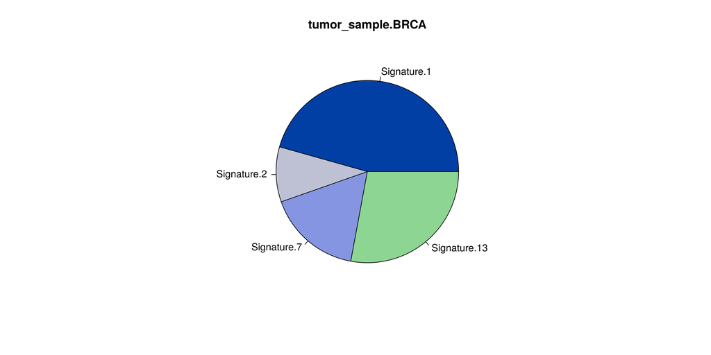

### Detected mutational signatures - proposed underlying aetiologies

|  | Signature_ID | Weight | Cancer_types | Proposed_aetiology | Comments |
| --- | --- | --- | --- | --- | --- |
| 1 | S1 | 0.456 | All cancer types | Endogenous mutational process initiated by spontaneous deamination of 5-methylcytosine, correlates with aging. |  |
| 2 | S13 | 0.279 | 22 cancer tyeps, most common in cervical and bladder cancers (usually in &gt; 10% of samples) | S13 has been attributed to activity of the AID/APOBEC family of cytidine deaminases converting cytosine to uracil. On the basis of similarities in the sequence context of cytosine mutations caused by … | S2 is usually found in the same samples as S13. It has been proposed that activation of AID/APOBEC cytidine deaminases is due to viral infection, retrotransposon jumping or to tissue inflammation. Cur… |
| 3 | S7 | 0.167 | Predominantly in skin cancers and in cancers of the lip categorized as head and neck or oral squamous cancers | Based on its prevalence in ultraviolet exposed areas and the similarity of the mutational pattern to that observed in experimental systems exposed to ultraviolet light S7 is likely due to ultraviolet … | Signature 7 is associated with large numbers of CC&gt;TT dinucleotide mutations at dipyrimidines. Additionally, Signature 7 exhibits a strong transcriptional strand-bias indicating that mutations occu… |
| 4 | S2 | 0.098 | 22 cancer types, most commonly in cervical and bladder cancers (usually in &gt; 10% of samples) | Activity of AID/APOBEC family of cytidine deaminases (APOBEC1, APOBEC3A and/or APOBEC3B) | S2 is usually found in the same samples as S13. It has been proposed that activation of AID/APOBEC cytidine deaminases is due to viral infection, retrotransposon jumping or to tissue inflammation. Cur… |

## References

Alexandrov, Ludmil B, Serena Nik-Zainal, David C Wedge, Samuel A J R Aparicio, Sam Behjati, Andrew Biankin V, Graham R Bignell, et al. 2013. “Signatures of Mutational Processes in Human Cancer.” *Nature*. Nature Publishing Group.

Alexandrov, Ludmil B, Serena Nik-Zainal, David C Wedge, Peter J Campbell, and Michael R Stratton. 2013. “Deciphering Signatures of Mutational Processes Operative in Human Cancer.” *Cell Rep.* 3 (1): 246–59.

Dong, Fei, Phani K Davineni, Brooke E Howitt, and Andrew H Beck. 2016. “A BRCA1/2 Mutational Signature and Survival in Ovarian High Grade Serous Carcinoma.” *Cancer Epidemiol. Biomarkers Prev.*, 5~aug.

Kim, Jaegil, Kent W Mouw, Paz Polak, Lior Z Braunstein, Atanas Kamburov, Grace Tiao, David J Kwiatkowski, et al. 2016. “Somatic ERCC2 Mutations Are Associated with a Distinct Genomic Signature in Urothelial Tumors.” *Nat. Genet.* 48 (6): 600–606.

Rosenthal, Rachel, Nicholas McGranahan, Javier Herrero, Barry S Taylor, and Charles Swanton. 2016. “DeconstructSigs: Delineating Mutational Processes in Single Tumors Distinguishes DNA Repair Deficiencies and Patterns of Carcinoma Evolution.” *Genome Biol.* 17 (1): 31.

Secrier, Maria, Xiaodun Li, Nadeera de Silva, Matthew D Eldridge, Gianmarco Contino, Jan Bornschein, Shona MacRae, et al. 2016. “Mutational Signatures in Esophageal Adenocarcinoma Define Etiologically Distinct Subgroups with Therapeutic Relevance.” *Nat. Genet.*, 5~sep.